# STAT340 HW2: Monte Carlo & Testing

Owen Jennings

2/28/22

## Instructions

Complete the exercises, update the “author” and “date” fields in the header, knit it, and submit **both the HTML and RMD** files to Canvas. Due date: **Mar 4, 2022 at 11:59pm**.

## Exercise 1 (20 points): Generalized [birthday problem](https://en.wikipedia.org/wiki/Birthday_problem)

The birthday problem asks for the probability that in a group of $n$ people, at least 2 people will share the same birthday. This is easy to solve, and the solution is easily found online.

We can generalize this to a more difficult problem and solve it using a Monte Carlo approach: in $n$ people, what is the probability that at least $k$ people have the same birthday?

Write a function `birthday(n,k,i)` that returns a probability estimate given 3 arguments:

- $n$ is the number of people in your sample
  - for example, if `n=50` is used, we are asking “in 50 people, what is the probability that…”
- $k$ is minimum number of people that must share a birthday
  - for example if `k=4` is used, we asking "…what is the probability that at least 4 people share the same birthday?
- $i$ is the number of iterations to run (default 1000)
  - for example, if `i=1000` is used, your function should run 1000 simulations

**Notes**:

- You may assume there are 365 possible dates (no leap years)
- You may assume birthdays are uniformly distributed across the calendar
  - this is actually not true, see [this](https://www.panix.com/~murphy/bday.html), or [this](https://fivethirtyeight.com/features/lots-of-parents-dont-want-their-kids-to-be-born-on-leap-day/)
- You may assume the people are sampled [i.i.d](https://en.wikipedia.org/wiki/Independent_and_identically_distributed_random_variables)

**Hints**:

1. There’s no need to use actual dates in the simulation process. Numbers can represent dates and are easier to generate and manipulate in `R`. In particular, we recommend using the `sample()` function with the `x`, `size`, and `replace` arguments set appropriately. See the help page `?sample` for details.
2. Given a vector of numbers, you can easily find duplicates by using the `table()` function. This will produce a named vector showing how many of each value there are. For example, running `table(c(1,3,5,5,7,9,9,9))` will show you there is one 1, one 3, two 5s, one 7, and three 9s.
3. In your function, you will need to use a `for` loop to repeat the simulation `i` times. You will also need a variable outside your `for` loop to keep track of how many simulations satisfy that # of birthdays $\geq k$.
4. If your function is running correctly, then `birthday(n=23, k=2)`, `birthday(n=87, k=3)` and `birthday(n=188, k=4)` should all be approximately $50\%$.
5. If your function is very slow, consider using the [`Table` function](https://rdrr.io/cran/Rfast/man/Table.html) from the Rfast package, which is 4-5 times faster than the normal `table()` function.

```r
# complete the function
# note i=1000 sets the default value of i to be 1000
birthday = function(n,k,i=1000){
  # code goes here
  x <- c(1:365)
  probability = 0
  for (trial in 1:i){
    s = sample(x, size = n, replace = TRUE)
    if (max(table(s)) >= k){
      probability = probability + 1
    }
  }
  return(probability/i)
}
```

This class currently has 162 enrolled students. What is the approximate probability that at least $4$ students have the same birthdays?

> About 33%.

## Exercise 2 (15 points): Simulate RV

$X$ is a random variable defined between $-\frac\pi2$ and $\frac\pi2$ by the probability density function $f(x)=\frac12\cos(x)$. Note this means the cumulative distribution function is
$$F(x)=\int_{-\frac\pi2}^xf(x)dx=\frac12(\sin(x)+1)$$
Write a function `rx(n)` to sample from this random variable, where `n` is the size of the sample to be drawn. Then, use your function to draw a sample of 1000 and plot a histogram of the output.

**Hint:** Remember the inverse function of $\sin(x)$ is $\arcsin(x)$, which in `R` is found by using the built in function `asin()`

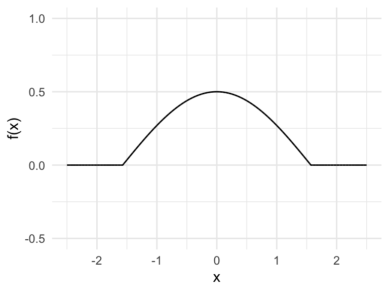

```r
# defining pdf of X
pdf_x = Vectorize(function(x){
  if(x>-pi/2 & x<pi/2){cos(x)/2} else 0
})

# showing pdf on plot
ggplot() + geom_function(fun=pdf_x,n=10001) + theme_minimal() +
  xlim(c(-2.5,2.5)) + ylim(-.5,1) + labs(x='x',y='f(x)')
```

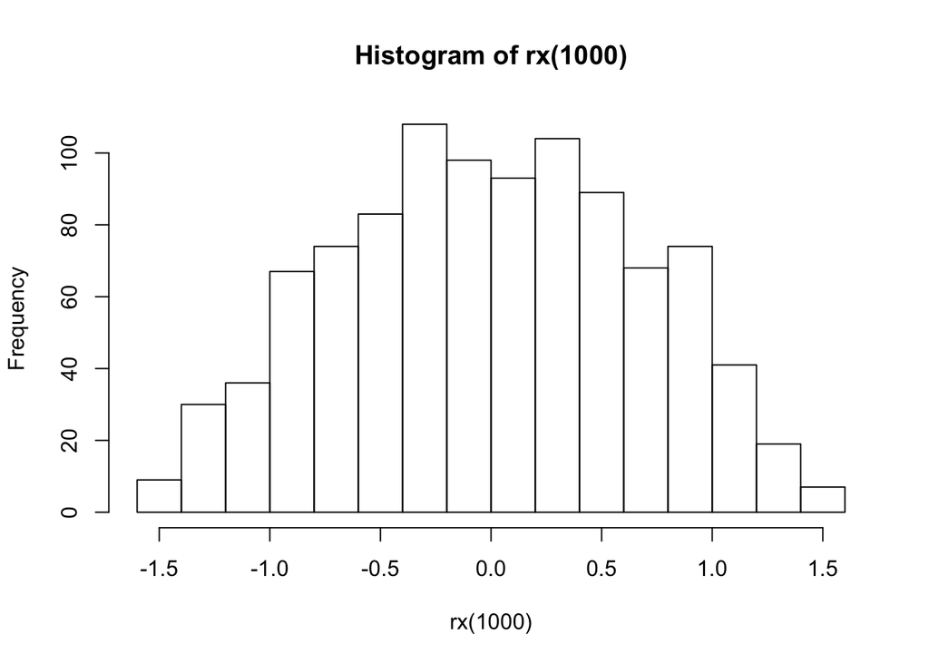

```r
# complete the function
y = function(x){
  asin(2*x-1)
}

rx = function(n){
  value <- runif(n)
  return(y(value))
}

# uncomment the following line of code and check it looks correct
hist(rx(1000))
```

## Exercise 3 (15 points): Testing coin flips

In the six sequences below, **only one** of them is actually randomly generated from a fair coin. Use a combination of everything you know (common sense, monte carlo, hypothesis testing, etc.) to identify which is actually random and explain your reasoning.

(*For full points*, conduct a formal test and report a $p$-value for each sequence. You may use a combination of multiple tests to arrive at your answer. If you cannot compute a $p$-value for each sequence, you can still earn a significant amount of partial credit by carefully explaining your reasoning and response as best as you can.)

```r
flips1 = "HTHTHTHTHTHTHTHTHTHTHTHTHTHTHTHTHTHTHTHTHTHTHTHTHTHTHTHTHTHT…"

flips2 = "HHHTHTTTHHTHHTHHHTTTTHTHTHHTTHTHHHTHHTHTTTHTHHHTHTTTHTHTHHTH…"

flips3 = "HHTHTHTTTHTHHHTHHTTTHTHHTHTTTHTHTHHTHTHTTHTHHHHHHTTTHTHTHHTH…"

flips4 = "HTHHHHHHHTHTTHHTTHHHTHTHTTTHHTHHHTHHTTHTTTTTTTTTHTHHTTTTTHTH…"

flips5 = "HHHHHHHHHHTTTTTTTTTTHHHHHHHHHHTTTTTTTTTTHHHHHHHHHHTTTTTTTTTT…"

flips6 = "TTHTTTHTTTTTTTHTHTHTHTTHTTHTHHTHHTTTHHTHTTTHTHHTHHHTHTTHHTHH…"

# you can use the function below to split the above sequences in vectors of flips
split = function(str) strsplit(str, split="")[[1]]
#split(flips1)
```

```r
longestRun = function(x,target = 'H'){
    max(0,with(rle(x), lengths[values==target]))
}

f1_run = longestRun(split(flips1))
f2_run = longestRun(split(flips2))
f3_run = longestRun(split(flips3))
f4_run = longestRun(split(flips4))
f5_run = longestRun(split(flips5))
f6_run = longestRun(split(flips6))
```

```r
simulate_S = function(){
  S = sample(c("H","T"), 1000,replace=T) %>% longestRun()
  return(S)
}

r = 10000
monte_carlo = data.frame(replicate = 1:r,
                         S = rep(NA,r),
                         S_in_A = rep(NA, r))

for(i in 1:r){
  monte_carlo$S[i] = simulate_S()
}
```

```r
check_if_S_in_A = function(S){
  return(S  <= f3_run)
}

for(i in 1:r){
  monte_carlo$S_in_A[i] = check_if_S_in_A(monte_carlo$S[i])

}

monte_carlo = as_tibble(monte_carlo)
p_value = monte_carlo %>% summarise(mean(S_in_A))
p_value
```

```
 # # A tibble: 1 × 1
 #   `mean(S_in_A)`
 #            <dbl>
 # 1         0.0205
```

```r
check_if_S_in_A = function(S){
  return(S  <= f4_run)
}

for(i in 1:r){
  monte_carlo$S_in_A[i] = check_if_S_in_A(monte_carlo$S[i])

}

monte_carlo = as_tibble(monte_carlo)
p_value = monte_carlo %>% summarise(mean(S_in_A))
p_value
```

```
 # # A tibble: 1 × 1
 #   `mean(S_in_A)`
 #            <dbl>
 # 1          0.145
```

Response goes here:

My conclusion is that the only randomly generated set of coin flips is 4. First, I ran longestRun tests for each set of coin flips for an initial test just to see what common sense can be used. Immediately I eliminated flips5 because the longest run was 10, and not only was it 10, but it was strings of 10. The probability of this is incredibly small and I felt comfortable eliminating these flips from testing. Next, I used longestRun simulation using Monte Carlo testing for each run, and with a significance level of 0.05, the only flips that failed to reject my null hypothesis of randomly generated flips were frlips #3 and flips #4. From here, I upped my sample size in my random generation from 200 to 1000. Upping the sample size would give me a more accurate view of random generation. My p-value for #3 was around .02, inside my 0.05 significance, and for #4 was around .14 which is outside. I felt confident I could reject my null hypothesis for #3 and I concluded that #4 is the randomly generated coin flips.